# lab2-general-concepts-ua

### Лабораторна робота 2: Основні поняття

В лабораторній роботі будемо використовувати данні щодо проданих на аукціоні автомобілів (`Carvana Car Prediction`). Цільовою ознакою є наявність прихованих продавцем суттевих недоліків.

Carvana — компанія, що перкупує автомобилі, і зрозуміло, що її задача — уникнути покупки автомобилів з прихованими недоліками (їх потім тяжк або неможливоо продати).

## 1

Завантажте дані щодо проданих на аукционі автомобилів. Перегляньте "сирі" (реальні) дані.

Передивитесь файл `Data_Dictionary.txt` щоб зрозуміти, що означають стовпчики матриці. Виведіть статистику по стовпчикам.

```python
import pandas as pd
```

```python
df = pd.read_csv('data.csv', delimiter=',')
df.describe()
```

|  | RefId | IsBadBuy | VehYear | VehicleAge | WheelTypeID | VehOdo | MMRAcquisitionAuctionAveragePrice | MMRAcquisitionAuctionCleanPrice | MMRAcquisitionRetailAveragePrice | MMRAcquisitonRetailCleanPrice | MMRCurrentAuctionAveragePrice | MMRCurrentAuctionCleanPrice | MMRCurrentRetailAveragePrice | MMRCurrentRetailCleanPrice | BYRNO | VNZIP1 | VehBCost | IsOnlineSale | WarrantyCost |
| --- | --- | --- | --- | --- | --- | --- | --- | --- | --- | --- | --- | --- | --- | --- | --- | --- | --- | --- | --- |
| count | 72983.000000 | 72983.000000 | 72983.000000 | 72983.000000 | 69814.000000 | 72983.000000 | 72965.000000 | 72965.000000 | 72965.000000 | 72965.000000 | 72668.000000 | 72668.000000 | 72668.000000 | 72668.000000 | 72983.000000 | 72983.000000 | 72983.000000 | 72983.000000 | 72983.000000 |
| mean | 36511.428497 | 0.122988 | 2005.343052 | 4.176644 | 1.494299 | 71499.995917 | 6128.909217 | 7373.636031 | 8497.034332 | 9850.928240 | 6132.081287 | 7390.681827 | 8775.723331 | 10145.385314 | 26345.842155 | 58043.059945 | 6730.934326 | 0.025280 | 1276.580985 |
| std | 21077.241302 | 0.328425 | 1.731252 | 1.712210 | 0.521290 | 14578.913128 | 2461.992768 | 2722.491986 | 3156.285284 | 3385.789541 | 2434.567723 | 2686.248852 | 3090.702941 | 3310.254351 | 25717.351219 | 26151.640415 | 1767.846435 | 0.156975 | 598.846788 |
| min | 1.000000 | 0.000000 | 2001.000000 | 0.000000 | 0.000000 | 4825.000000 | 0.000000 | 0.000000 | 0.000000 | 0.000000 | 0.000000 | 0.000000 | 0.000000 | 0.000000 | 835.000000 | 2764.000000 | 1.000000 | 0.000000 | 462.000000 |
| 25% | 18257.500000 | 0.000000 | 2004.000000 | 3.000000 | 1.000000 | 61837.000000 | 4273.000000 | 5406.000000 | 6280.000000 | 7493.000000 | 4275.000000 | 5414.000000 | 6536.000000 | 7784.000000 | 17212.000000 | 32124.000000 | 5435.000000 | 0.000000 | 837.000000 |
| 50% | 36514.000000 | 0.000000 | 2005.000000 | 4.000000 | 1.000000 | 73361.000000 | 6097.000000 | 7303.000000 | 8444.000000 | 9789.000000 | 6062.000000 | 7313.000000 | 8729.000000 | 10103.000000 | 19662.000000 | 73108.000000 | 6700.000000 | 0.000000 | 1155.000000 |
| 75% | 54764.500000 | 0.000000 | 2007.000000 | 5.000000 | 2.000000 | 82436.000000 | 7765.000000 | 9021.000000 | 10651.000000 | 12088.000000 | 7736.000000 | 9013.000000 | 10911.000000 | 12309.000000 | 22808.000000 | 80022.000000 | 7900.000000 | 0.000000 | 1623.000000 |
| max | 73014.000000 | 1.000000 | 2010.000000 | 9.000000 | 3.000000 | 115717.000000 | 35722.000000 | 36859.000000 | 39080.000000 | 41482.000000 | 35722.000000 | 36859.000000 | 39080.000000 | 41062.000000 | 99761.000000 | 99224.000000 | 45469.000000 | 1.000000 | 7498.000000 |

```python
df.head()
```

|  | RefId | IsBadBuy | PurchDate | Auction | VehYear | VehicleAge | Make | Model | Trim | SubModel | ... | MMRCurrentRetailAveragePrice | MMRCurrentRetailCleanPrice | PRIMEUNIT | AUCGUART | BYRNO | VNZIP1 | VNST | VehBCost | IsOnlineSale | WarrantyCost |
| --- | --- | --- | --- | --- | --- | --- | --- | --- | --- | --- | --- | --- | --- | --- | --- | --- | --- | --- | --- | --- | --- |
| 0 | 1 | 0 | 12/7/2009 | ADESA | 2006 | 3 | MAZDA | MAZDA3 | i | 4D SEDAN I | ... | 11597.0 | 12409.0 | NaN | NaN | 21973 | 33619 | FL | 7100.0 | 0 | 1113 |
| 1 | 2 | 0 | 12/7/2009 | ADESA | 2004 | 5 | DODGE | 1500 RAM PICKUP 2WD | ST | QUAD CAB 4.7L SLT | ... | 11374.0 | 12791.0 | NaN | NaN | 19638 | 33619 | FL | 7600.0 | 0 | 1053 |
| 2 | 3 | 0 | 12/7/2009 | ADESA | 2005 | 4 | DODGE | STRATUS V6 | SXT | 4D SEDAN SXT FFV | ... | 7146.0 | 8702.0 | NaN | NaN | 19638 | 33619 | FL | 4900.0 | 0 | 1389 |
| 3 | 4 | 0 | 12/7/2009 | ADESA | 2004 | 5 | DODGE | NEON | SXT | 4D SEDAN | ... | 4375.0 | 5518.0 | NaN | NaN | 19638 | 33619 | FL | 4100.0 | 0 | 630 |
| 4 | 5 | 0 | 12/7/2009 | ADESA | 2005 | 4 | FORD | FOCUS | ZX3 | 2D COUPE ZX3 | ... | 6739.0 | 7911.0 | NaN | NaN | 19638 | 33619 | FL | 4000.0 | 0 | 1020 |

5 rows × 34 columns

## 2

Побудуйте графік: вісь абсцис - пробіг, вісь ординат - ціна `MMRCurrentRetailAveragePrice`. Відмітте автомобиілі без недоліків зеленим кольором, з прихованими недоліками — червоним.

```python
%matplotlib inline
import matplotlib.pyplot as plt
```

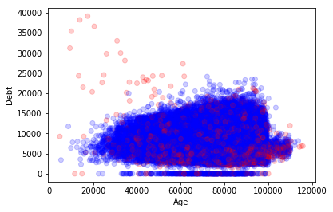

```python
colors = {0:'blue', 1:'red'}
plt.scatter(df['VehOdo'], df['MMRCurrentRetailAveragePrice'], marker='o', alpha = 0.2, c=df['IsBadBuy'].map(colors));
plt.xlabel('Age')
plt.ylabel('Debt');
```

# Регресія

## 3a

Імпортуйте з бібліотеки `sklearn` всі моделі машинного навчання:

`from sklearn import *`

Трактуючи задачу передбачення наяаності недоліків як задачу регресіїи, натренуйте лінійну модель [`LinearRegression`](https://scikit-learn.org/stable/modules/generated/sklearn.linear_model.LinearRegression.html) на якійсь підмножині ознак (наприклад, `VehOdo` и `MMRCurrentRetailAveragePrice`).

Яка виникла проблема? Які способи її розвязання Ви пропонуєте?

*Функції, що можуть стати у пригоді при розв'язанні: `.fit(), .loc[], pd.notnull()`*

*Створення моделі:* `model1 = linear_model.LinearRegression()`

*Тренування:* `model1.fit(x, y)`

```python
# Виникла проблема, що деякі клітинки не містять дані, тому виникає помилка:
# ValueError: Input contains NaN, infinity or a value too large for dtype('float64').
# Тому ми спершу вибираємо колонки, які нас цікавлять і тоді обробляємо дані, а саме ми можемо просто викинути
# рядки, що не містять даних (їх доволі небагато, менше 400 із 72983)
# Можна було би скористатись методом fillna і заповнити пропуски наприлад середніми значеннями,
# проте це внесе деякі ноточності у дані
df_subset = df[['VehOdo', 'MMRCurrentRetailAveragePrice', 'IsBadBuy']]
df_subset = df_subset.dropna()
```

```python
print(len(df))
print(len(df_subset))
```

```
72983
72668
```

```python
from sklearn import *
X = df_subset[['VehOdo', 'MMRCurrentRetailAveragePrice']]
y = df_subset['IsBadBuy']
model = linear_model.LinearRegression()
model.fit(X, y)
```

```
LinearRegression(copy_X=True, fit_intercept=True, n_jobs=None,
         normalize=False)
```

## 3b

Зробіть передбачення щодо всіх об'єктів навчальної вибірки, результат - в змінну prediction

*Функції, що можуть стати у пригоді при розв'язанні: `model.predict()`*

```python
prediction = model.predict(X)
prediction
```

```
array([0.12473569, 0.13585101, 0.14563746, ..., 0.12108278, 0.12349799,
       0.07867021])
```

## 3c

Перетворіть отриманий вектор передбачень `prediction` в значення `{0,1}`. Це можна зробити, наприклад, за допомогою list comprehensions: https://docs.python.org/3/tutorial/datastructures.html#list-comprehensions

`predictionClass = [1 if prediction[i] > 0.5 else 0 for i in range(prediction.shape[0])]`

```python
predictionClass = [1 if prediction[i] > 0.2 else 0 for i in range(prediction.shape[0])]
```

## 3d

Побудуйте звіт щодо якості класифікації и матрицю помилокк. Як змінеться звіт і матриця помилок, якщо змінити поріг в завданні 3c (за замовченням 0.5)?

*Функції, що можуть стати у пригоді при розв'язанні: `print(metrics.classification_report(...))`, `print(metrics.confusion_matrix(...))`*

Функція classification_report для кожного класу об'єктів рахує точність (precision) в цьому класі и повноту (recall). Повнота - це процент об'єктів цього класа, які метод передбачення відніс до цього класу, серед всіх об'ектів цього класу. Точність (precision) - те ж саме, тілько серед всіх об'ектів, що передбачені для цього класу.

Функція confusion_matrix повертає матрицю з кількістями об'ектів. Номери стовпчиків матриці - це номери передбаченихых класів, рядки - це номери правильних класів. Наприклад, елемент M[0,1] - кількість машин, де в дійсності IsBadBuy = 0, а ми передбачили 1.

```python
from sklearn.metrics import confusion_matrix
print(metrics.classification_report(y, predictionClass))
print(metrics.confusion_matrix(y, predictionClass))
```

```
              precision    recall  f1-score   support

           0       0.88      0.97      0.92     63724
           1       0.26      0.09      0.13      8944

   micro avg       0.86      0.86      0.86     72668
   macro avg       0.57      0.53      0.53     72668
weighted avg       0.81      0.86      0.82     72668

[[61528  2196]
 [ 8166   778]]
```

# Класификація

## 4a

Трактуючи задачу как задачу класификації, будуємо модель класификації «вирішуюче дерево» глибиною 20 (все аналогично линійної регресії).

*Функції, що можуть стати у пригоді при розв'язанні: `tree.DecisionTreeClassifier(max_depth=20)`*

```python
model = tree.DecisionTreeClassifier(max_depth=20)
model = model.fit(X, y)
```

## 4b

Вирішальне дерево передбачає імовірності. За допомогою попобудованої модели рахуємо імовірності наявності прихованих недоліків.

*Функції, що можуть стати у пригоді при розв'язанні: `model.predict_proba()`*

```python
prediction = model.predict_proba(X)
```

## 4c

Перетворіть отриманий вектор передбачень `prediction` до значень `{0,1}`. Будємо звіт щодо класификації і матрицю помилок. Який метод краще?

```python
predictionClass = [1 if prediction[i][0] < 0.5 else 0 for i in range(prediction.shape[0])]
```

```python
print(metrics.classification_report(y, predictionClass))
print(metrics.confusion_matrix(y, predictionClass))
```

```
              precision    recall  f1-score   support

           0       0.91      1.00      0.95     63724
           1       0.96      0.31      0.47      8944

   micro avg       0.91      0.91      0.91     72668
   macro avg       0.94      0.65      0.71     72668
weighted avg       0.92      0.91      0.89     72668

[[63623   101]
 [ 6184  2760]]
```

```python
# Дерево рішень дало кращі результати у порівнянні із лінійною регресією
```